# 5 Seksuaalirikokset

*Tiina Malin & Tea Hatunen*

## 5.2

Tässä luvussa tarkastellaan seksuaalirikoksia, jotka on listattu rikoslain 20 luvussa. Tarkastelun pääpaino on raiskausrikoksissa (RL 20:1–2) sekä lapsiin kohdistuvissa seksuaalirikoksissa (RL 20:12–16), joiden osalta esitellään rikosten määrällistä kehitystä sekä piirteitä. Luvun lopussa kuvataan vielä rikoslain 20 luvun muiden nimikkeiden sekä joidenkin rikoslain 17 luvun rikosten määriä.

Vuoden 2023 alusta tuli voimaan lainmuutos, joka uudisti rikoslain 20 luvun (ks. HE 13/2022 vp.). Tiivistetysti muutoksen myötä rikosten tunnusmerkistöt laajentuivat ja rangaistukset ankaroituivat. Yksi keskeisimmistä muutoksista on ollut raiskauksen suostumusperusteisuus. Lapsiin kohdistuneet seksuaalirikokset on erotettu kokonaan omiksi nimikkeikseen. Suostumusperusteisuus koskee myös lapsiin kohdistuneita seksuaalirikoksia, joista sukupuoliyhteyden sisältäneet arvioidaan uuden lain mukaan lähtökohtaisesti aina lapsenraiskauksena (perusmuotoinen ja törkeä tekomuoto). Muut teot arvioidaan seksuaalisena kajoamisena lapseen tai sen törkeänä tekomuotona. Edelleen kuitenkin myös lapsen seksuaalinen hyväksikäyttö voi tulla kyseeseen olosuhteista riippuen. Edellisiin vaikuttaa keskeisesti myös sukupuoliyhteyden määritelmän laajentaminen kattamaan myös sukuelimen tai peräaukon koskettelun suulla tai sukuelimellä (RL 20:23).

Muutokset, jotka koskevat muita kuin raiskausrikoksia ja lapsiin kohdistuvia rikoksia, käsitellään tarkemmin alaluvussa 4.3. Näistä keskeisimpiä ovat seksuaalisen ahdistelun laajeneminen koskemaan muitakin kuin koskettelua sisältäviä tekoja sekä seksuaalisen kuvan luvatta levittämisen kriminalisointi.

4.1 Raiskaus

Raiskausrikokset on porrastettu törkeysasteeltaan kahteen tekomuotoon, raiskaukseen (RL 20:1) ja törkeään raiskaukseen (RL 20:2). Raiskausrikosten kehitystä kuvataan tässä raportissa sekä viranomaisten tietoon tulleiden rikosten että kokonaisrikollisuuden osalta. Viranomaisten tietoon tulleiden rikosten lähteenä käytetään Tilastokeskuksen rikos- ja pakkokeinotilastoa, joka kuvaa poliisin, Tullin ja Rajavartiolaitoksen tietoon tullutta rikollisuutta. Kuitenkin oletettavasti vain pieni osa seksuaalirikoksista tulee viranomaisten tietoon ja viranomaistilastojen tueksi tarvitaankin kyselypohjaisia tietolähteitä. Kokonaisrikollisuuden kuvaamiseen käytetään kansallista rikosuhritutkimusta, joka on 15–74-vuotiaille suunnattu, kansallisesti edustava kysely (tarkemmin ks. kohta A.3.1).

### 5.2.1 Rikollisuuden kehitys

Raiskausrikoksilla tarkoitetaan seuraavissa tarkasteluissa raiskausta ja törkeää raiskausta (RL 20:1–2), mukaan lukien näiden yritykset. Näitä tuli viranomaisten tietoon yhteensä 2 162 rikosta vuonna 2024. Lukumäärä oli korkeampi kuin edellisenä vuonna, ja rikosten määrä onkin ollut pääosin noususuhtainen koko tarkasteltavan kymmenvuotiskauden. Vuonna 2024 raiskausrikoksista yhdeksän prosenttia oli tekomuodoltaan *törkeitä*. Törkeiden raiskausten määriä tarkasteltaessa on huomioitava, että törkeän lapsenraiskauksen säännöksen voimaantulon (vuonna 2019) jälkeen osa aiemmin törkeän raiskauksen nimikkeellä viranomaisten tietoon tulleista rikoksista on siirtynyt uuden nimikkeen alle, eivätkä sisälly enää törkeiden raiskausten tarkasteluun. Lisäksi vuodesta 2023 eteenpäin kaikki alle 16-vuotiaisiin kohdistuneet raiskaukset arvioidaan ainoastaan lapsenraiskauksina (RL 20:12 tai 20:13), kun aiemmin ne on kirjattu myös perusmuotoisina tai törkeinä raiskauksina. Kuvion 1 luvut sisältävät myös ne teot, joita poliisi on tutkinut raiskausrikoksen *yrityksenä*. Raiskausrikoksen yritykseksi nimettyjen tekojen osuus vuonna 2024 oli viisi prosenttia kaikista tietoon tulleista raiskausrikoksista.

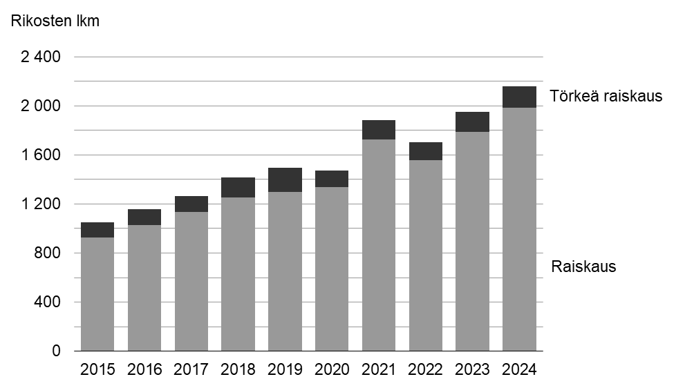

Vuonna 2024 raiskausrikosten lukumäärä nousi vuoteen 2023 verrattuna, taso oli vertailuvuosien 2015-2024 korkein.

**Kuvio 1** Viranomaisten tietoon tulleet raiskausrikokset vuosina 2015–2024. *Lähde*: Tilastokeskus, rikos- ja pakkokeinotilasto (Tilastokeskus 2025a)

Edellä esitetyt tiedot perustuvat rikosten, ei tekijöiden määriin; sama tekijä on voinut syyllistyä useaan rikokseen vuoden aikana. Jos tarkastelu rajataan niin, että yksi henkilö voi esiintyä vuoden aikana vain kerran rikoksen tekijänä törkeimmän rikoksensa mukaan, raiskausrikoksesta epäiltyjen määrä on vuodesta 2015 vuoteen 2024 kasvanut 536 henkilöstä 1 051 henkilöön. Tekijäpohjaisen laskennan kuvaaman muutoksen suunta ja mittaluokka ovat pääosin samanlaiset kuin rikoksia laskettaessa. Raiskausrikosten määrän nousua pidemmällä aikavälillä selittänevät ainakin osittain tekojen määritelmiä laajentaneet lainmuutokset. Tuoreimman muutoksen lisäksi rikosten määritelmiä on laajennettu vuosina 2011 ja 2014. Lisäksi on syytä huomioida, että lainmuutoksen ollessa tekeillä raiskausrikokset ja seksuaalirikokset olivat vahvasti esillä julkisessa keskustelussa. Tämä on osaltaan saattanut lisätä ihmisten tietoisuutta siitä, minkälaiset teot täyttävät rikosen tunnusmerkit tai lisätä ilmoitusalttiutta.

Seksuaalirikokset, joihin liittyy uhrin kuolemaan johtanutta väkivaltaa, ovat verraten harvinaisia. Henkirikollisuuden seurantajärjestelmän mukaan vuosina 2013–2023 henkirikoksista 0,9 prosentissa tapahtui oheisrikoksena raiskaus ja 0,4 prosentissa muu seksuaalinen teko (Törölä & Raeste 2025.)

Kansalliseen uhritutkimukseen liitettiin vuonna 1997 kysymyksiä koskien seksuaaliseen kanssakäymiseen pakottamisen ja sen yrityksen uhriksi joutumista. Vuosina 2013–2023 (pois lukien vuosi 2022, jolloin kyselyä ei toteutettu) kysely on toteutettu nimellä Kansallinen rikosuhritutkimus (KRT) ja näiden vuosien tulokset ovat olleet myös sekä kysymysmuotoilujen että kyselymenetelmän suhteen vertailukelpoisia keskenään. Tuoreimman, vuonna 2023 toteutetun, kyselyn vastauksissa edeltävässä kyselyssä havaittu nousu on tasaantunut. Tulosten osalta on syytä huomioida, etteivät vuositasojen muutokset ole olleet tilastollisesti merkitseviä[^4]. Vuoden 2023 kyselyssä 3 prosenttia naisista ja 0,5 prosenttia miehistä ilmoitti joutuneensa sukupuoliyhteyteen tai muuhun seksuaaliseen kanssakäymiseen pakottamisen (ml. yritys) kohteeksi kyselyä edeltäneen 12 kuukauden aikana (taulukko 1).

**Taulukko 1** Sukupuoliyhteyteen tai muuhun seksuaaliseen kanssakäymiseen pakottaminen tai pakottamisen yritys viimeisen 12 kuukauden aikana, % 15–74-vuotiaista

|  | *2013* | *2014* | *2015* | *2016* | *2017* | *2018* | *2019* | *2020* | *2021* | *2023* |
| --- | --- | --- | --- | --- | --- | --- | --- | --- | --- | --- |
| Naiset | 2,3 | 1,6 | 2,2 | 2,2 | 2,2 | 2,5 | 2,8 | 2,8 | 3,2 | 3,0 |
| Miehet | 0,4 | 0,4 | 0,3 | 0,7 | 0,5 | 0,6 | 0,3 | 0,5 | 1,0 | 0,5 |

*Lähde:* Kansallinen rikosuhritutkimus 2013–2023 (ks. Beuker & Näsi 2024).

Kysely sisältää myös jatkokysymyksen siitä, kuinka moni sukupuoliyhteyteen tai muuhun seksuaaliseen kanssakäymiseen pakotetuksi joutuneista (pl. yritykset) ilmoitti rikoksesta viranomaisille. Matalan vuosittaisen vastaajamäärän johdosta tarkastelussa on kolmen edellisen kyselyn (2020, 2021 ja 2023) vastaukset. Näinä vuosina sukupuoliyhteyteen tai muuhun seksuaaliseen kanssakäymiseen pakotetuiksi joutuneista valtaosa (81 prosenttia) ei ilmoittanut asiasta viranomaiselle.

Vaihtoehtoisen tarkastelukulman uhrikokemuksiin tuo Rikosuhripäivystyksen (RIKU:n) asiakasdata. RIKU on tuki- ja neuvontapalvelu rikoksen uhrille, tämän läheiselle ja rikosasian todistajalle. RIKU tilastoi asiakkuuksien määrän osin anonyymisti, eli tilastoista ei voida täysin erottaa päällekkäisiä asiakkuuksia. Kuitenkin raiskausrikoksiin liittyvien asiakkuuksien määrä on huomattavan suuri. RIKU:ssä oli vuonna 2024 keskimäärin 988 raiskausrikoksiin liittyvää asiakkuutta kuukaudessa, kun esimerkiksi viranomaisten tietoon tulleen rikollisuuden määrä samana vuonna oli keskimäärin 180 ilmoitusta kuukaudessa. RIKU:n mukaan vuonna 2024 seksuaalirikokset olivat toiseksi yleisin syy asiakkuuteen lähisudeväkivallan jälkeen (Rikosuhripäivystys 2025).

### 5.2.2 Raiskausten piirteitä

Raiskausrikosten teonpiirteitä on seuraavassa kuvattu pääosin (ja mikäli erikseen ei mainita muuta) Tilastokeskuksen rikos- ja pakkokeinotilaston pohjalta. Tarkastelussa on monin paikoin hyödynnetty kolmen viimeisimmän vuoden (2022–2024) tietoja, koska rikosepäilyjen lukumäärä eri ryhmissä voi vaihdella yksittäisinä vuosina melko voimakkaastikin. Tilastokeskuksen tilastoissa kuvatut rikokset koskevat osin kaikkia viranomaisten tietoon tulleita ja osin selvitettyjä rikoksia, joiden kokonaismäärät vaihtelevat hieman. Koska viranomaislähteissä ei juuri kuvata rikosten teonpiirteitä, lähteenä on hyödynnetty myös selvitystä, jossa on tarkasteltu vuosina 2014–2016 viranomaisten tietoon tulleiden raiskausten teonpiirteitä (Vauhkonen

ym. 2021)[^5]

*Sukupuoli*. Vuosina 2022–2024 selvitettyjen raiskausrikosten tekijöistä 98,1 prosenttia oli miehiä ja 1,9 prosenttia naisia. Uhrien sukupuolijakauma oli pitkälti päinvastainen: 95,9 prosenttia naisia ja 4,1 prosenttia miehiä. Myös kyselytutkimusten mukaan sukupuolten välinen ero on huomattava (ks. Taulukko 1), mutta niissä ero on hieman vähäisempi kuin viranomaisten tietoon tulleissa raiskausrikoksissa.

*Ikä.* Kuviossa 2 on tarkasteltu raiskausrikoksista epäiltyjä iän mukaan suhteessa kunkin ikäryhmän kokoon vuosina 2022–2024. Tarkasteluun on otettu 13–63-vuotiaat. Rajauksena perusteena on se, tätä nuorempia ja vanhempia epäiltyjä on erittäin vähän. Kuviosta havaitaan, että raiskausrikoksista epäiltyjen ikäjakauma painottuu vahvasti nuorimpiin ikäluokkiin: ikäryhmän kokoon suhteutettuna eniten rikoksista epäiltyjä on 17–22-vuotiaiden keskuudessa, suurimman epäiltyjen ikäryhmän kokoon suhteutettuna ollessa 18-vuotiaat.

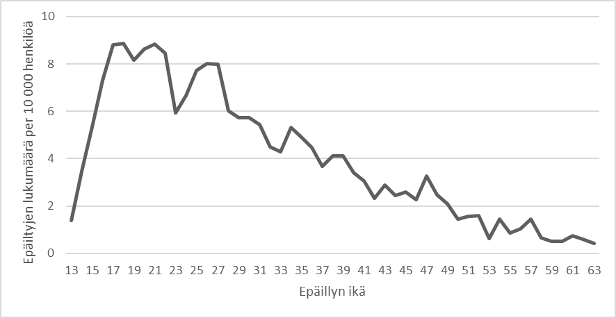

Sisältö kerrottu edeltävässä tekstiosuudessa.

**Kuvio 2** Raiskausrikoksista epäiltyjä epäillyn iän mukaan (13–63-vuotiaat) 10 000 henkeä kohti, viranomaisten tietoon vuosina 2022–2024 tulleet rikokset. *Lähteet:* Tilastokeskus, rikos- ja pakkokeinotilasto (Tilastokeskus 2025a); Tilastokeskus, väestörakenne (Tilastokeskus 2025b).

Tilastokeskuksen rikos- ja pakkokeinotilastosta ilmenee, että vuosina 2022–2024 raiskausrikosten uhreista 25,9 prosenttia oli alle 18-vuotiaita ja 47,3 prosenttia 18–29-vuotiaita. Samansuuntaisia tuloksia on saatu myös Kansallisessa rikosuhritutkimuksessa. Vuoden 2023 kyselyssä 9,7 prosenttia 15–24-vuotiaista naisista ilmoitti, että häneen oli edeltävän vuoden aikana kohdistunut pakottamista (ml. yritys) sukupuoliyhteyteen tai muuhun seksuaaliseen kanssakäymiseen. 25–34-vuotiaiden naisten ryhmässä osuus oli 4,3 prosenttia, 35–54-vuotiaiden ryhmässä 1,9 prosenttia ja tätä vanhemmissa ikäryhmissä 0,4 prosenttia. Miesten osalta vastaavat osuudet olivat 1,1 prosenttia 15–24-vuotiaista, 1,2 prosenttia 25–34-vuotiaista sekä alle prosentin vanhemmissa ikäryhmissä. Vuoden 2023 lainmuutoksen myötä alle 16-vuotiaiden lukumäärän raiskausrikosten uhreina odotetaan laskevan. Tämän suuntaista kehitystä on jo havaittavissa rikos- ja pakkokeinotilastossa, jossa alle 18-vuotiaiden raiskausrikosten uhrien osuus on laskenut neljä prosenttiyksikköä vuodesta 2023 ja lähes kahdeksan prosenttiyksikköä vuodesta 2022.

*Tekopaikka.* Valtaosa raiskausrikoksista tapahtuu yksityisissä tiloissa. Vuonna 2024 viranomaisten tietoon tulleista raiskausrikoksista 77,7 prosentissa tekopaikkana oli yksityinen asunto ja 11,1 prosentissa muu yksityinen paikka. Kaikkiaan siis 88,9 prosenttia raiskausrikoksista tapahtui yksityisissä tiloissa. Osuus on viimeisen kymmenen vuoden aikana vaihdellut 79 ja 90 prosentin välillä. Muualla tapahtuneissa raiskausrikoksissa oli valtaosin kyse tilastokategoriasta “muu yleinen paikka”.

*Päihteiden rooli*. Vuosina 2022–2024 selvitettyihin rikoksiin syylliseksi epäillyistä 23 prosenttia oli alkoholin, muun päihteen tai näiden yhdistelmän vaikutuksen alaisena. Näistä valtaosa tapahtui vain alkoholin vaikutuksen alaisena. Kuitenkin suuressa osassa tapauksia päihtymystila jäi selvittämättä: 68 prosentissa tapauksista päihtymystila oli kirjattu tuntemattomaksi. Uhrien osalta rikosilmoituksiin perustuvan tarkastelun mukaan 57 prosenttia raiskauksen ja 36 prosenttia törkeän raiskauksen uhreista olivat päihtyneitä (Vauhkonen ym. 2021).

*Osapuolten suhde*. Rikos- ja pakkokeinotilastossa ei eritellä osapuolten suhdetta. Tilastokanta pitää kuitenkin sisällään poliisin rikosepäilyihin perustuvan Tilastokeskuksen luokitteleman tietokantataulukon perhe- ja lähisuhdeväkivallasta, jonka pohjalta voidaan tarkastella puolisoiden tai entisten puolisoiden välillä tapahtuneiden rikosten lukumääriä. Parisuhteessa tai entisessä parisuhteessa tapahtuneita raiskausrikoksia (RL 20:1–2) on raportoitu 187 vuonna 2024, 182 vuonna 2023 ja 120 vuonna 2022. Rikosilmoituksiin pohjautuvan selvityksen mukaan noin puolessa raiskaustapauksissa tekijä ja uhri ovat olleet tuttuja keskenään (Vauhkonen ym. 2021).

*Tekijän kansalaisuus*. Vuonna 2024 ulkomaan kansalaisten osuus selvitettyjen raiskausrikosten epäilyistä oli 28 prosenttia (404 epäiltyä). Kymmenen edeltävän vuoden aikana osuus on vaihdellut 21 ja 38 prosentin välillä. Vuonna 2024 (vakituisesti Suomessa asuvia) ulkomaan kansalaisia oli epäiltynä 5,8 henkilöä 10 000 asukasta kohti, kun vastaava luku Suomen kansalaisilla oli 1,5 henkilöä[^6].

Joiltakin osin ulkomaalaistaustaisten yliedustusta raiskausrikoksista epäillyissä selittää väestön nuori ikärakenne. Laajan maahanmuuttajien rikollisuutta käsitelleen tutkimuksen (Lehti ym. 2014) mukaan vuosina 2010–2011 maahanmuuttajien rikostaso oli syntyperäisiä suomalaisia korkeampi lähes kaikissa maahanmuuttajaryhmissä. Tilastokeskuksen vuosia 2017–2018 koskevassa selvityksessä ulkomaan kansalaisten ikä- ja sukupuolivakioitu suhteellinen riski joutua raiskausrikoksesta epäillyksi oli noin kuusinkertainen Suomen kansalaisiin nähden. Irakin kansalaisilla osuus oli noin 16-kertainen, Somalian kansalaisilla kuusinkertainen ja Viron kansalaisilla kolminkertainen (Tilastokeskus 2019).

*Selvitysprosentti*. Selvitysprosentilla tai selvitysasteella kuvataan selvitettyjen rikosten osuutta tilastointivuonna tietoon tulleista rikoksista. Selvitysprosentin lasku on haastavaa, sillä rikokset eivät useinkaan tule viranomaisten tietoon, että selvitetyksi saman kalenterivuoden aikana. Siksi luku voidaan laskea kahdella eri tavalla, koostamalla selvitetyt rikokset joko sellaisista rikoksista, jotka ovat sekä tulleet ilmi että selvitetty kyseisenä tilastovuonna tai laskemalla mukaan kaikki kyseisenä vuonna selvitetyt rikokset (sisältäen myös aiempina vuosina ilmitulleita rikoksia). Tässä katsauksessa on perinteisesti käytetty ensimmäistä laskutapaa, jonka mukaan vuonna 2024 tietoon tulleista raiskausrikoksista selvitettiin vuoden loppuun mennessä 16,9 prosenttia. Selvitysaste on ollut viitenä viimeisenä vuotena (2020–2024) keskimäärin 21,5 prosenttia. Selvitysprosentti on lähes kymmenen yksikköä pienempi kuin jaksoa edeltäneen viiden vuoden (2015–2019) selvitysprosentti (32 %). Raiskausrikosten pidentyneet esitutkinta-ajat vaikuttavat tämän laskutavan mukaisen selvitysprosentin laskuun (ks. Fagerlund & Toivonen 2021).

*Rikosten alueellinen jakautuminen*. Kuviossa 3 on esitetty viranomaisten tietoon tulleet raiskausrikokset vuonna 2024 maakunnittain alueen 10 000 asukasta kohti. Eniten rikoksia suhteessa asukaslukuun on raportoitu Pohjois-Savossa (6,83 raiskausrikosta 10 000 asukasta kohti) ja vähiten Kanta-Hämeessä (2,18 rikosta 10 000 asukasta kohti). Vaihtelua kuitenkin oletettavasti osittain selittävät rikosten eroavat kirjaamiskäytännöt esimerkiksi tekokokonaisuuksien osalta.

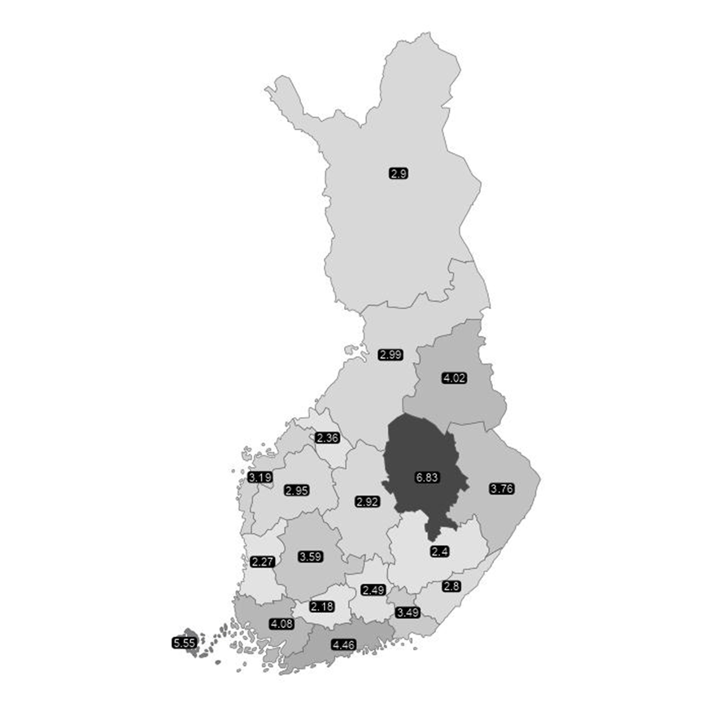

**Kuvio 3** Viranomaisten tietoon tulleet raiskausrikokset (RL 20:1–2) 10 000 asukasta kohti maakunnittain 2024. *Lähde*: Tilastokeskus, rikos- ja pakkokeinotilasto (Tilastokeskus 2025a)

4. 2 Lapsiin ja varhaisnuoriin kohdistuvat seksuaalirikokset

Lapsiin kohdistuvat seksuaalirikokset on vuoden 2023 lainmuutoksen jälkeen täysin erotettu aikuisiin kohdistuneista seksuaalirikoksista. Uuden lainsäädännön keskeinen ero aiempaan on se, että sukupuoliyhteyden sisältäneet teot arvioidaan nyt aina lähtökohtaisesti lapsenraiskauksina (perusmuotoinen ja törkeä, RL 20:12–13). Aiemmin nämä teot olisi tuomittu törkeinä tai perusmuotoisina lapsen seksuaalisina hyväksikäyttöinä ja osa, pakottamista tai uhkaamista sisältäneet teot, myös raiskauksina. Uusi lainsäädäntö kuitenkin pohjautuu ajatukselle, ettei alle 16-vuotias voi antaa suostumustaan sukupuoliyhteyteen. Laki sisältää edelleen rajoitussäännöksen (RL 20:17), ja olosuhteiden arvioinnin myötä rikoksia on mahdollista tuomita myös muilla nimikkeillä. Seksuaalinen kajoaminen lapseen ja törkeä seksuaalinen kajoaminen lapseen (RL 20:14–15) vastaavat entisiä lapsen seksuaalisia hyväksikäyttöjä muiden kuin sukupuoliyhteyden kattavien tekojen osalta. Rangaistusasteikko on noussut törkeän seksuaalisen kajoamisen osalta niin, että minimirangaistus on kahden vuoden vankeus ja maksimi kymmenen vuoden vankeus. Edelleen teot, jotka ovat lapsen ja tekijän ikä ja kypsyys, osapuolten suhde sekä muut teko-olosuhteet huomioon ottaen rikoksen vakavuutta vähentävien seikkojen vallitessa tehty, voidaan arvioida lapsen seksuaalisina hyväksikäyttöinä (RL 20:16).

### 5.2.3 Rikollisuuden kehitys

*Viranomaisten tietoon tullut rikollisuus*. Lainsäädäntö muuttui vuoden 2023 alusta, mutta koskee tekoja, jotka ovat tapahtuneet uuden lain voimassaollessa. Tästä syystä viranomaiset ovat uuden lain voimassaolon jälkeenkin kirjanneet vanhentuneilla rikosnimikkeillä tapahtuneita rikoksia. Tässä katsauksessa viranomaisten tietoon tulleita rikoksia pyritään tarkastelemaan mahdollisimman vertailukelpoisesti aiempiin vuosiin nähden, vaikka rikosten määritelmien muututtua tämä ei olekaan täysin mahdollista.

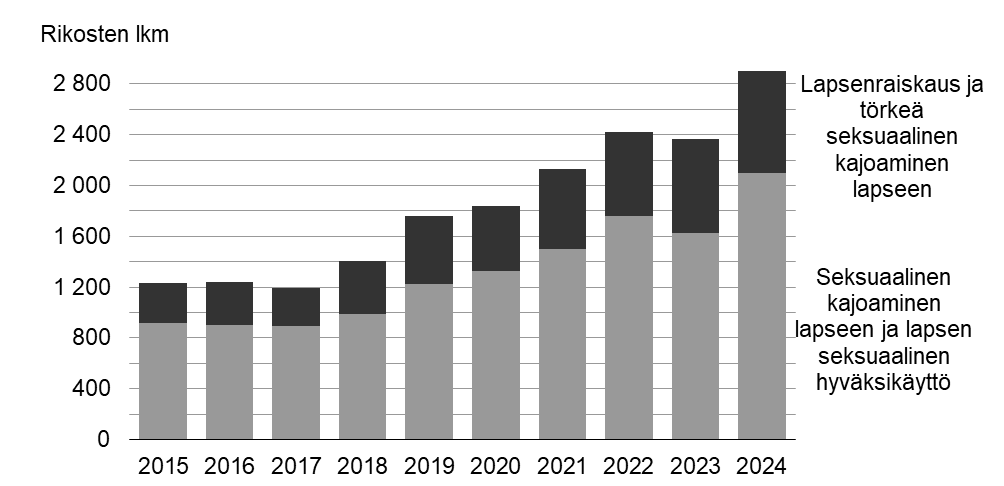

Sisältö on kerrottu kuviota seuraavassa tekstiosuudessa

**Kuvio 4** Viranomaisten tietoon tulleet seksuaaliset kajoamiset lapseen, lapsen seksuaaliset hyväksikäytöt ja lapsenraiskaukset vuosina 2015–2024. *Lähde*: Tilastokeskus, rikos- ja pakkokeinotilasto (Tilastokeskus 2025a)

Poliisin selvitetyksi merkitsemiä lapsiin kohdistuvia seksuaalirikoksia oli vuonna 2024 yhteensä 1 800 (1 394 vuonna 2023). Kuviossa 5 on esitetty kaikkien näiden ilmoitettujen ja selvitettyjen rikosten määrät vuosittain, mutta koska osa merkitään selvitetyiksi eri vuonna kuin rikosilmoitus on kirjattu, koskevat saman vuoden luvut ilmoitetuista ja selvitetyistä rikoksista osin eri tapauksia.

Pidemmällä aikavälillä tarkasteltuna havaitaan, että vuosittain ilmoitettujen tapausten määrä on moninkertaistunut vuodesta 1980 (kuvio 5). Tilastoitujen rikosten määrän kasvu ei kuitenkaan yksiselitteisesti viittaa pelkästään siihen, että lasten seksuaalinen hyväksikäyttö olisi ilmiönä lisääntynyt, vaan taustalla on muun muassa viranomaiskontrollin tehostuminen ja kiinnijäämisriskin kasvu (ks. myös Hinkkanen 2009, 12). Lisäksi rikossarjat voivat vaikuttaa huomattavasti vuosittain tilastoitujen rikosten määrään. Rikosten kirjaamiskäytäntö on epäyhtenäinen erityisesti silloin, kun sama henkilö on joutunut toistuvasti hyväksikäytön uhriksi. Toisinaan rikossarja kirjataan yhtenä ja toisinaan useana rikoksena.

Toisaalta esimerkiksi lapsen seksuaalinen hyväksikäyttö internetin välityksellä sekä lapsen houkutteleminen seksuaalisiin tarkoituksiin eli niin sanottu grooming ovat olleet laajamittaisemmin mahdollisia vasta 2000-luvun alun tienoilta, ja viimeksi mainittu lisättiin rikoslakiin vuonna 2011.

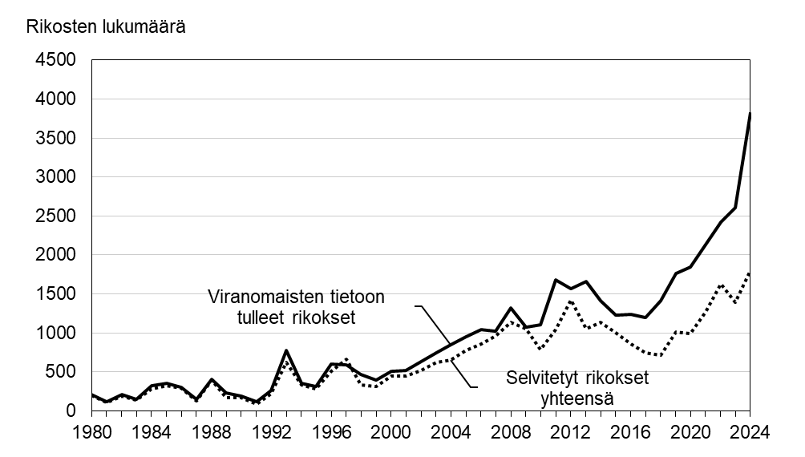

Viranomaisten tietoon tulleet lapsen seksuaaliset hyväksikäytöt ovat lisääntyneet selvästi vuosina 1980-2024.

**Kuvio 5** Seksuaalinen kajoaminen lapseen, lapsen seksuaalinen hyväksikäyttö ja lapsenraiskaus 1980–2024, viranomaisten tietoon tulleet rikokset ja selvitetyt rikokset vuosittain. *Lähde*: Tilastokeskus, rikos- ja pakkokeinotilasto (Tilastokeskus 2025a)

Tekojen arkaluontoisuuden vuoksi lapsiin kohdistuneita seksuaalisia hyväksikäyttöjä ei läheskään aina ilmoiteta poliisille tai muille viranomaisille. Lapsi voi salata asian vanhemmiltaan, ja vanhemmatkaan eivät aina halua tehdä hyväksikäytöstä rikosilmoitusta. Jos hyväksikäyttäjänä on lapsen vanhempi tai muu perheenjäsen, rikoksen poliisille ilmoittaminen on paljolti riippuvainen siitä, tuleeko epäily ilmi muuta kautta esimerkiksi päiväkodissa, koulussa tai sosiaali- ja terveyspalvelujen yhteydessä.

Vuoden 2013 lapsiuhritutkimuksessa kysyttiin, oliko lapsi tai nuori kertonut seksuaalikokemuksesta aikuisen tai vähintään viisi vuotta vanhemman kanssa ja jos kyllä, kenelle (Fagerlund ym. 2014, 119–120). Niistä, joilla seksuaalikokemuksia oli ja jotka vastasivat kysymykseen kokemuksesta kertomisesta (247 vastaajaa), kuusi prosenttia oli kertonut poliisille. Terveydenhoitajalle, koulukuraattorille ja/tai sosiaalityöntekijälle oli kertonut 2–5 prosenttia vastaajista. Lähes puolet oli kertonut seksuaalikokemuksesta aikuisen kanssa kaverille, ja 19 prosenttia ei ollut kertonut kenellekään. Ruotsissa on arvioitu, että lasten seksuaalisista hyväksikäytöistä noin 3–12 prosenttia tulee poliisin tietoon (Brå 2007)

Rikosten ilmoitusalttiudessa tapahtuneet muutokset ovat voineet vaikuttaa ilmi tulleiden rikosten määrän kehitykseen. Osa uutisoiduista seksuaalirikostapauksista on herättänyt suurta mediahuomiota, ja kampanjointi sekä julkinen keskustelu seksuaalisesta häirinnästä ja hyväksikäyttörikoksista on voinut laskea ilmoituskynnystä vanhempienkin tekojen osalta (esim. Haapakangas 2020). Viranomaisten ilmoitusvelvollisuuksiin ja tiedonvaihtoon on tehty viime vuosien aikana lainsäädännöllisiä muutoksia, mikä myös lisää lapsiin kohdistuvien rikosten ilmituloa (Mathews ym. 2016). Suomessa lastensuojelussa ja poliisissa on lisäksi 2000-luvun aikana panostettu lapsiin kohdistuneiden rikosten tunnistamiseen ja tutkimiseen erityisesti viranomaisia kouluttamalla (esim. Ellonen & Rantaeskola 2016; Fagerlund & Toivonen 2021).

*Kokonaisrikollisuus*. Kokonaisrikollisuuden näkökulmasta lapsen seksuaalisen hyväksikäytön yleisyyttä on selvitetty lapsille ja nuorille suunnattujen lapsiuhritutkimusten avulla. Kuudes- ja yhdeksäsluokkalaisille suunnatut laajat kyselytutkimukset väkivaltakokemuksista toteutettiin vuosina 2008 (Ellonen ym. 2008), 2013 (Fagerlund ym. 2014) ja 2022 (Mielityinen ym. 2023). Yhdeksäsluokkalaisten osalta tuloksia voidaan verrata Sariolan (1990) vuonna 1988 toteuttamaan koululaiskyselyyn. Lähes kokonaiset ikäluokat tavoittavissa Kouluterveyskyselyissä (esim. Ikonen & Helakorpi 2019) on puolestaan eri vuosina kysytty vaihtelevin kysymyksenasetteluin seksuaalisesta väkivallasta ja häirinnästä.

**Taulukko 2** Seksuaalikokemukset aikuisten ja vähintään 5 vuotta vanhempien kanssa, %

|  | 1988 | 2008 | 2013 | 2019 | 2022 |
| --- | --- | --- | --- | --- | --- |
| Tytöt | 17 | 13 | 8 | 8 | 11 |
| Pojat | 6 | 3 | 3 | 2 | 2 |
| Yhteensä | 12 | 8 | 5 | 5 | 7 |

*Lähteet:* Lapsiuhritutkimukset 1988, 2008, 2013 ja 2022 (9 lk.) (Mielityinen ym. 2023, liitetaulukko 59); Kouluterveyskysely 2019 (8–9 lk.) (Terveyden ja hyvinvoinnin laitos 2019)

Edellä taulukossa 2 esiteltyä kysymystä seksuaalikokemuksista vähintään viittä vuotta vanhemman kanssa ei ole vuoden 2019 jälkeen sisällytetty Kouluterveyskyselyyn. Kuitenkin tuoreemmat, vuosien 2021, 2023 ja 2025, kyselyt ovat sisältäneet kysymykset seksuaaliväkivallasta, häiritsevästä seksuaalisesta ehdottelusta ja ahdistelusta sekä seksuaalisen häirinnän kokemuksista puhelimessa ja internetissä sekä julkisessa tilassa viimeksi kuluneen vuoden aikana. Seksuaalisen häirinnän indikaattori kuvaa niiden osuutta, jotka ovat vastanneet kokeneensa viimeisen vuoden aikana häiritsevää seksuaalista ehdottelua tai ahdistelua eri paikoissa. Vuoden 2025 kyselyssä 31 prosenttia kahdeksas- ja yhdeksäsluokkalaisista tytöistä ja 12 prosenttia pojista raportoi vähintään yhdestä seksuaalisen häirinnän kokemuksesta. Vastaavat luvut olivat 45 ja 12 vuonna 2023 ja 48 ja 11 vuonna 2021 (Terveyden ja hyvinvoinnin laitos 2025). Kokemukset ovat siis tuoreessa kyselyssä vähentyneet merkittävästi tyttöjen osalta.

On katsottu, että internetin, älypuhelinten ja sosiaalisen median sovellusten käytön yleistyminen on lisännyt mahdollisuuksia hyväksikäyttöön (esim. Broome, Izura & Lorenzo-Dus 2018; Kloess ym. 2019). Kontakteja potentiaalisiin uhreihin voidaan tehdä internetin välityksellä suuria määriä, jolloin tekijöiden on mahdollista löytää itselleen helpoimmat uhrit. Lapsiuhritutkimuksen tulosten mukaan verkossa tapahtunut seksuaalinen häirintä on ollut pidemmällä aikavälillä kasvussa. Tuoreimman, vuonna 2022 toteutetun kyselyn mukaan 34 prosenttia yhdeksäsluokkalaisista tytöistä ja 18 prosenttia pojista oli viimeisen vuoden aikana kokenut seksuaalista häirintää verkossa (Mielityinen ym. 2023). Aiemmassa, vuoden 2013, kyselyssä vastaavat luvut olivat 16 prosenttia tytöistä ja seitsemän prosenttia pojista (Fagerlund ym. 2014). Muutos on tilastollisesti merkitsevä. Tuorein Kouluterveyskysely näyttää kuitenkin verkkovälitteisen seksuaalisen häirinnän kokemusten vähentyneen. Puhelimen tai netin välityksellä häiritsevää seksuaalista ahdistelua ilmoitti vuonna 2025 kokeneensa 23 prosenttia kahdeksas- ja yhdeksäsluokkalaisista tytöistä ja seitsemän prosenttia saman ikäisistä pojista. Aiemmissa kyselyissä vastaavat luvut olivat 38 ja yhdeksän vuonna 2023 sekä 42 ja yhdeksän vuonna 2021. (Terveyden ja hyvinvoinnin laitos 2025.).

### 5.2.4 Ilmi tulleen rikollisuuden piirteitä

Lasten seksuaalisesta hyväksikäytöstä tuomituista ja tuomioista on tehty erityiset selvitykset vuosina 2009 ja 2020 (Hinkkanen 2009; Malin 2020). Näiden perusteella voidaan tarkastella joitakin mahdollisia muutoksia ilmi tulleen rikollisuuden piirteisiin sekä uhreihin ja tekijöihin liittyen. Tuorein selvityksistä on toteutettu Kriminologian ja oikeuspolitiikan instituutissa ja sen aineisto sisältää vuosina 2017–2018 lainvoimaisiksi tulleet käräjä- ja hovioikeuksien tuomiot lapsiin kohdistuneiden seksuaalirikosten osalta (Malin 2020). Uhrien ja rikoksista epäiltyjen ikään ja sukupuoleen liittyvät tiedot on kerätty Tilastokeskuksen rikos- ja pakkokeinotilastosta.

*Ikä ja sukupuoli*. Vuonna 2024 viranomaisten tietoon tulleista lapsiin kohdistuneista seksuaalirikoksista 96,2 prosentissa epäilty tekijä oli mies. Kuviosta 6 nähdään, että vuosina 2022–2024 tietoon tulleissa tapauksissa epäillyt painottuvat alle 30-vuotiaisiin. Eri ikäryhmien välillä on suurtakin vaihtelua ja isommat piikit aineistossa saattavat liittyä suurempiin tekokokonaisuuksiin. Kuvion tarkastelu rajoittuu 6–77-vuotiaisiin johtuen nuorempien ja vanhempien ikäluokkien esiintyvyyksien mataluudesta. Vuonna 2024 viranomaisten tietoon tulleiden lapsiin kohdistuneiden seksuaalirikosten (perusmuotoinen ja törkeä lapsen seksuaalinen hyväksikäyttö, perusmuotoinen ja törkeä lapsenraiskaus, perusmuotoinen seksuaalinen kajoaminen lapseen) uhreista vajaa kolme neljäsosaa (73 %) oli tyttöjä. Iältään uhrit painottuivat 12–14-vuotiaisiin, jotka muodostivat 49 prosenttia uhreista.

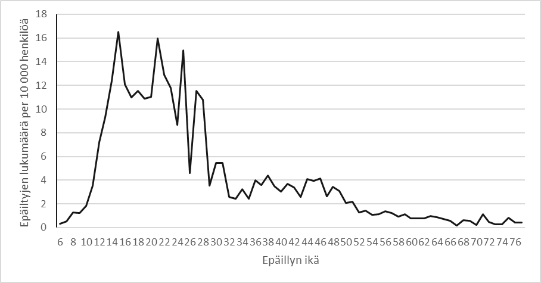

Sisältö kerrottu edeltävässä tekstiosuudessa.

**Kuvio 6** Lapsiin kohdistuneista seksuaalirikoksista[^7] epäiltyjä epäillyn iän mukaan (6–77-vuotiaat) 10 000 henkeä kohti, viranomaisten tietoon vuosina 2022–2024 tulleet rikokset. *Lähteet:* Tilastokeskus, rikos- ja pakkokeinotilasto (Tilastokeskus 2025a); Tilastokeskus, väestörakenne (Tilastokeskus 2025b)

*Osapuolten välinen suhde.* Tuomituista rikoksentekijöistä 12 prosenttia oli uhrin vanhempia tai vanhempien kumppaneita, yhteensä perheensisäisiä tapauksia oli vajaa viidesosa. Seurustelukumppanien osuus tekijöistä oli 10 prosenttia ja uhrin kaverien tai tuttavien osuus neljäsosa. Ennalta tuntemattomien tekemiä hyväksikäyttöjä oli 13 prosenttia (Malin 2020).

*Fyysisen väkivallan käyttö*. Rikosilmoitustietojen mukaan lapsen seksuaalisissa hyväksikäyttötapauksissa (25 %) ja törkeissä lapsen seksuaalisissa hyväksikäyttötapauksissa (27 %) fyysistä väkivaltaa (seksuaalisen väkivallan lisäksi) kuvattiin joka neljännessä tapauksessa (Vauhkonen ym. 2021).

*Tekijöiden piirteitä nuorten ilmoittamana.* Nuorisorikollisuuskyselyn tietojen mukaan lapsiin ja nuoriin kohdistuvassa seksuaaliväkivallassa tekijöitä on yleensä vain yksi. Tekijä oli uhrin mukaan yleensä taustaltaan suomalainen, mutta aikuisten tekemässä seksuaalisessa väkivallassa tekijä oli hieman useammin ulkomaalaistaustainen kuin nuorten tekemässä väkivallassa. Seksuaalisen väkivallan tekijät ovat usein nuorille tuttuja henkilöitä. Tekijä on useammin tuntematon aikuisen kuin toisen nuoren tekemässä seksuaalisessa väkivallassa. Tekijä on vain harvoin henkilö, joka on tavattu vain verkossa. (Vauhkonen ym. 2021)

*Verbaalinen ja fyysinen seksuaaliväkivalta*. Nuorisorikollisuuskyselyn tietojen mukaan aikuisten tekemissä teoissa seksuaalinen kommentointi ja seksuaaliset teot sekä niihin suostutteleminen tai painostaminen olivat yleisempiä kuin toisten nuorten tekemässä väkivallassa. Toisten nuorten teot sisälsivät yleisemmin ahdistelevia viestejä, kuvien ja juorujen levittämistä ja fyysistä väkivaltaa. Tuntemattoman tekijän seksuaalinen väkivalta oli yleisemmin seksuaalissävytteistä kommentointia ja sisälsi harvemmin suostuttelua seksuaaliseen tekoon. Tuntemattoman nuoren tekemä seksuaalinen väkivalta taas käsitti useammin ahdistelevien viestien lähettelyä ja harvemmin häiritsevää koskettelua tai fyysistä väkivaltaa. (Vauhkonen ym. 2021)

**Muita teonpiirteitä.** Vuonna 2011 sukupuoliyhteyden sisältävät teot siirtyivät törkeän lapsen seksuaalisen hyväksikäytön tunnusmerkistöön. Muutoksen jälkeen sukupuoliyhteyden osuus perusmuotoisena tuomituissa teoissa on pudonnut 50 prosentista viidesosaan teoista ja törkeissä teoissa noussut kahdesta kolmasosasta tekoja 86 prosenttiin (16 prosenttia sisältää pakottamisen elementtejä) (Malin 2020; Hinkkanen 2009). Vastaavasti koskettelua sisältäneiden tekojen osuus lisääntyi perusmuotoisissa teoissa ja väheni törkeissä teoissa.

Vuosina 2017–2018 käräjä- ja hovioikeuksissa lainvoimaisiksi tulleista lapsiin kohdistuneista seksuaalirikoksista 16 prosenttia tapahtui verkkoympäristössä ja 21 prosenttia nettituttujen toteuttamina (Malin 2020). Netin kautta uhriin tutustuneen tekijän onnistui reilussa puolessa tapauksista sopia tapaaminen uhrin kanssa kasvotusten. Näiden tekojen osuus oli aineistossa huomattavasti suurempi kuin aiemmassa kyselytutkimuksessa (esim. Fagerlund ym. 2014). Osasyy tähän on luultavasti se, että vakavampia tekoja päätyy tuomittaviksi asti lievempiä tekoja enemmän, jolloin niitä esiintyy tuomioistuinaineistossa yleisemmin kuin kyselyaineistossa.

*Selvitysprosentti*. Selvitysprosentti lasketaan perustuen poliisin esitutkinnan päätteeksi tekemiin merkintöihin, jolloin tapaus merkitään selvitetyksi ja se voidaan siirtää syyttäjälle syyteharkintaan. Selvitysprosentti raportoidaan tässä julkaisussa laskemalla tilastovuonna ilmoitetut ja samana vuonna selvitetyt rikokset prosentteina kaikista vuoden aikana ilmoitetuista rikoksista. Vuonna 2024 tietoon tulleista lapsen seksuaalisista hyväksikäytöistä selvitettiin vuoden loppuun mennessä 20 prosenttia (14 prosenttia vuonna 2023). Koska rikoslaji pitää sisällään välillä suuriakin tekokokonaisuuksia, saattaa selvitysprosentti jäädä hyvinkin alhaiseksi, kun rikokset tulevat viranomaisten tietoon ja selvitetyiksi usein eri vuosina. Tähän vaikuttavat myös rikosprosessin kestoajat. Lapsiin kohdistuneiden seksuaalirikosten käsittelyajat koko rikosprosessissa poliisin esitutkinnasta käräjäoikeuden ratkaisuun asti ovat myös pidentyneet vuosina 2014–2019 (Fagerlund & Toivonen 2021). Rikossarjojen kirjaamiskäytäntöjen epäyhtenäisyys ja selvittämiseen kuluva aika vaikuttavat siten, että vuosittaiset vaihtelut selvitysprosentissa voivat olla hyvinkin suuria.

*Rikosten alueellinen jakautuminen*. Kuviossa 7 on esitetty viranomaisten tietoon tulleet lapsiin kohdistuvat seksuaalirikokset vuonna 2024 maakunnittain 10 000 asukasta kohti. Tilastokeskuksen ryhmittelykäytännön takia kuvattuna on seuraavat rikosnimikkeet: lapsen seksuaalinen hyväksikäyttö, seksuaalinen kajoaminen lapseen, korvauksen tarjoaminen nuoreen kohdistuvasta seksuaalisesta teosta sekä lapsen houkutteleminen seksuaalisiin tarkoituksiin.

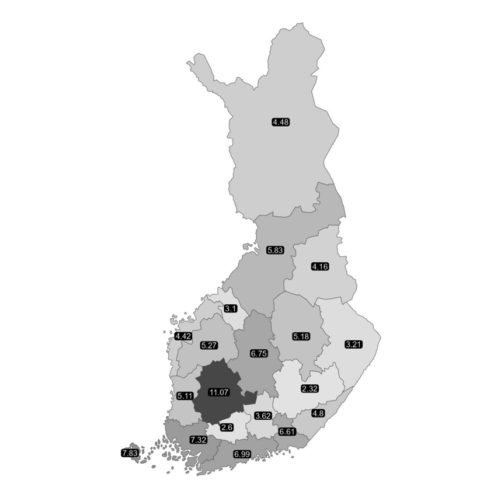

Sisältö kerrottu edeltävässä tekstiosuudessa.

**Kuvio 7.** Viranomaisten tietoon tulleet lapsiin kohdistuneet seksuaalirikokset (RL 20:14–16, 20:18) 10 000 asukasta kohden maakunnittain 2024. *Lähde*: Tilastokeskus, rikos- ja pakkokeinotilasto (Tilastokeskus 2025a).

4.3 Muut seksuaalirikokset

Tämä luku sisältää tietoja muista seksuaalirikoksista kuin raiskausrikoksista ja lapsiin kohdistuvista seksuaalirikoksista. Tähän joukkoon sisältyvät loput rikoslain 20 lukuun kuuluvat säännökset sekä rikoslain 17 lukuun kuuluvia nimikkeitä. Taulukossa 4 on kuvattu kaikki luvussa esiteltävät rikosnimikkeet sekä niiden lukumäärä kolmena edeltävänä vuonna. Taulukosta käyvät ilmi myös uudet, vuoden 2023 alusta voimassa olleet rikosnimikkeet. Rikosnimikkeitä kuvataan hieman tarkemmin seuraavassa kahdessa alaluvussa.

**Taulukko 4** Viranomaisten tietoon tulleet muut rikoslain 20 ja 17 lukujen seksuaalirikokset 2022–2024

|  | 2022 | 2023 | 2024 |
| --- | --- | --- | --- |
| Muut rikoslain 20 luvun rikokset |  |  |  |
| Seksuaalinen kajoaminen (ent. pakottaminen seksuaaliseen tekoon) | 175 | 358 | 471 |
| Seksuaalisen kajoamisen yritys (ent. seksuaaliseen tekoon pakottamisen yritys) | 34 | 8 | 10 |
| Törkeä seksuaalinen kajoaminen | .. | 18 | 10 |
| Törkeän seksuaalisen kajoamisen yritys | .. | 0 | 0 |
| Seksuaalinen hyväksikäyttö | 107 | 105 | 60 |
| Seksuaalisen hyväksikäytön yritys | 9 | 3 | 7 |
| Seksuaalinen ahdistelu | 776 | 1283 | 1526 |
| Seksuaalisen kuvan luvaton levittäminen | .. | 145 | 156 |
| Seksikaupan kohteena olevan henkilön hyväksikäyttö | 0 | 3 | 4 |
| Seksikaupan kohteena olevan henkilön hyväksikäytön yritys | 0 | 0 | 0 |
| Korvauksen tarjoaminen nuoreen kohdistuvasta seksuaalisesta teosta |  |  |  |
| (ent. seksuaalipalvelujen ostaminen nuorelta) | 138 | 210 | 99 |
| Korvauksen tarjoamisen yritys nuoreen kohdistuvasta seksuaalisesta teosta |  |  |  |
| (ent. seksuaalipalvelujen ostamisen yritys nuorelta) | 74 | 48 | 51 |
| Paritus | 7 | 17 | 18 |
| Parituksen yritys | 1 | 0 | 1 |
| Törkeä paritus | 10 | 6 | 5 |
| Törkeän parituksen yritys | 0 | 0 | 0 |
| Lapsen houkutteleminen seksuaalisiin tarkoituksiin | 118 | 261 | 122 |
| Lapsen seksuaalisiin tarkoituksiin houkuttelemisen yritys | 22 | 32 | 24 |
| Lasta seksuaalisesti esittävän kuvan levittäminen | .. | 321 | 660 |
| Lasta seksuaalisesti esittävän kuvan levittämisen yritys | .. | 0 | 7 |
| Törkeä lasta seksuaalisesti esittävän kuvan levittäminen (ent. törkeä sukupuolisiveellisyyttä loukkaavan lasta esittävän kuvan levittäminen) | 60 | 7 | 20 |
| Törkeä lasta seksuaalisesti esittävän kuvan levittämisen yritys (ent. sukupuolisiveellisyyttä loukkaavan lasta esittävän kuvan törkeän levittämisen yritys) | 0 | 2 | 0 |
| Lasta seksuaalisesti esittävän kuvan hallussapito (ent. sukupuolisiveellisyyttä loukkaavan lasta esittävän kuvan hallussapito/hallussa pitäminen) | 537 | 419 | 669 |
| Lasta seksuaalisesti esittävän esityksen seuraaminen (ent. sukupuolisiveellisyyttä loukkaavan lasta koskevan esityksen seuraaminen) | 1 | 2 | 2 |
| Lasta seksuaalisesti esittävän esityksen seuraamisen yritys (ent. sukupuolisiveellisyyttä loukkaavan lasta koskevan esityksen seuraamisen yritys) | 0 | 0 | 0 |
| Rikoslain 17 luvun rikokset |  |  |  |
| Sukupuolisiveellisyyttä loukkaavan kuvan levittäminen | 400 | 127 | 89 |
| Sukupuolisiveellisyyttä loukkaavan kuvan levittämisen yritys | 2 | 2 | 0 |
| Kuvaohjelman laiton esittäminen tai levittäminen alaikäiselle | 1 | 1 | 0 |
| Sukupuolisiveellisyyttä loukkaava markkinointi | 0 | 0 | 0 |
| Sukupuolisiveellisyyden julkinen loukkaaminen | 199 | 159 | 152 |
| Sukupuoliyhteys lähisukulaisten kesken | 28 | 17 | 9 |

*Lähde*: Tilastokeskus, rikos- ja pakkokeinotilasto (Tilastokeskus 2025a).

.. Säännös ei voimassa

*Muut rikoslain 20 luvun rikokset*. Rikos- ja pakkokeinotilaston mukaan muita seksuaalirikoksia (RL 20:3–11, 20:18–22) tuli viranomaisten tietoon 3 922 tapausta vuonna 2024 (3 248 tapausta vuonna 2023 ja 1 472 vuonna 2022). Ilmi tulleiden tapausten määrät ovat vaihdelleet vuositasolla jonkin verran, mutta pääpiirteittäin tapausten yhteenlaskettu määrä on noussut melko tasaisesti viimeisen kymmenen vuoden ajan. Nousuun ovat vaikuttaneet myös uudet kriminalisoinnit, vuoden 2023 lisäksi esimerkiksi seksuaalinen ahdistelu (nyk. RL 20:6) tuli voimaan 1.9.2014. Lisäksi vuoden 2023 alusta tuli voimaan useita uusia nimikkeitä, ja osan jo olemassa olevien rikosten määritelmät laajenivat kattamaan enemmän tekomuotoja. Vuoden 2023 alussa osa aiemmin rikoslain 17 luvussa olleista nimikkeistä myös siirtyi rikoslain 20 luvun alle.

Aiempi RL 20:4, pakottaminen seksuaaliseen tekoon, on korvattu nimikkeellä seksuaalinen kajoaminen (RL 20:3). Uusi määritelmä pohjautuu suostumuksen puutteeseen aiemman väkivallan käytön tai sillä uhkaamisen sijaan ja siitä on olemassa myös törkeä tekomuoto (RL 20:4). Vuonna 2024 seksuaalisia kajoamisia (RL 20:3 ja 20:4) kirjattiin yrityksineen yhteensä 491 kappaletta (384 vuonna 2023 ja pakottamisia seksuaaliseen tekoon 209 vuonna 2022). Seksuaalisesta hyväksikäytöstä (RL 20:5) rangaistaan henkilöä, joka asemaansa hyväksikäyttäen pakottaa henkilön sukupuoliyhteyteen tai muuhun seksuaalista itsemääräämisoikeutta olennaisesti loukkaavaan seksuaaliseen tekoon. Vuonna 2024 poliisi kirjasi 67 seksuaalista hyväksikäyttöä tai sen yritystä.

Lainmuutos laajensi seksuaalisen ahdistelun (RL 20:6) määritelmän kattamaan koskettelemalla tehtyjen seksuaalisten tekojen lisäksi tekoja, jotka vakavuudeltaan vastaavat koskettelua. Rikosnimike tuli alun perin voimaan 2014 ja sen tapausmäärät ovat nousseet huomattavasti tämän jälkeen. Vuonna 2024 seksuaalisia ahdisteluja tuli viranomaisten tietoon 1 526 tapausta (1 283 tapausta vuonna 2023 ja 776 vuonna 2022).

Uuden lainsäädännön myötä kriminalisoitiin myös seksuaalisen kuvan luvaton levittäminen (RL 20:7). Kuvan esittäminen tai levittäminen toisen itsemääräämisoikeutta loukkaavasti on kielletty, vaikka kuvan ottamiseen olisi ollut suostumus. Mikäli suostumusta on rikottu kuvaa ottaessa, teko voi täyttää seksuaalisen kajoamisen tai seksuaalisen ahdistelun tunnusmerkistön. Vuonna 2024 rikosnimikettä (RL 20:7) tuli viranomaisten tietoon 156 tapausta.

Prostituutio ei ole Suomessa kategorisesti rangaistavaa. Seksuaalipalvelujen ostaminen parituksen tai ihmiskaupan kohteena olevalta henkilöltä on kuitenkin rangaistavaa rikosnimikkeellä seksikaupan kohteena olevan henkilön hyväksikäyttö (RL 20:8). Viime vuosina näitä rikoksia on tullut varsin vähän viranomaisten tietoon: vuonna 2024 neljä, vuonna 2023 kolme ja vuonna 2022 ei yhtään. Rangaistavaa on myös seksuaalipalvelujen ostaminen 18 vuotta nuoremmalta henkilöltä. Vuodesta 2023 rikosnimikkeenä on ollut korvauksen tarjoaminen nuoreen kohdistuvasta seksuaalisesta teosta (aiemmin seksuaalipalvelujen ostaminen nuorelta). Näitä rikoksia (RL 20:9) tai rikoksen yrityksiä tuli viranomaisten tietoon 150 rikosta vuonna 2024, 258 vuonna 2023 ja 212 vuonna 2022.

Rikoslain 20 luku pitää sisällään rikosnimikkeet myös parituksesta (RL 20:10) sekä törkeästä parituksesta (RL 20:11). Kriminalisoinnin keskeinen tarkoitus on suojata prostituoituja heitä hyväkseen käyttäviltä parittajilta. Viimeisen vuosikymmenen aikana ilmitulleiden paritusrikosten määrät ovat vaihdelleet vuositasolla melko paljon. Viimeisenä kolmena vuotena rikoksia yrityksineen on ilmoitettu 24 vuonna 2024, 23 vuonna 2023 ja 18 vuonna 2022. Tapausmäärien suurta vaihtelua voivat selittää esimerkiksi poliisin paritustoimintaan kohdistaman kontrollin intensiteetin vaihtelu sekä suuret tekokokonaisuudet, jotka paljastuessaan voivat nostaa vuosittaista määrää huomattavasti.

Vuonna 2011 rikoslakiin lisättiin rangaistussäännös, jolla kriminalisoitiin lapsen houkutteleminen seksuaalisiin tarkoituksiin (RL 20:18). Rangaistavaa on ehdottaa tapaamista tai muuta kanssakäymistä lapsen kanssa siten, että tarkoituksena on lapsen seksuaalinen hyväksikäyttö tai lasta sukupuolisiveellisyyttä loukkaavasti esittävien kuvien valmistaminen. Tällaisia rikoksia (yrityksineen) tuli viranomaisten tietoon yhteensä 146 vuonna 2024 (293 vuonna 2023 ja 140 vuonna 2022). Samaan aikaan edellisen kanssa kriminalisoitiin sukupuolisiveellisyyttä loukkaavan lasta koskevan esityksen seuraaminen, jonka nimi vaihtui 2023 lasta seksuaalisesti esittävän esityksen seuraamiseksi (RL 20:22). Tällaiset teot eivät kuitenkaan vaikuta tulevan usein viranomaisten tietoon, sillä näitä rikoksia kirjattiin vuonna 2024 vain kaksi tapausta, 2023 kaksi tapausta ja 2022 yksi tapaus.

Lasta seksuaalisesti esittävän kuvan levittämistä (RL 20:19) yrityksineen tuli viranomaisten tietoon 667 tapausta vuonna 2024. Vastaavasti rikoksen törkeää tekomuotoa (RL 20:20) tuli viranomaisten tietoon yrityksineen 20 kappaletta vuonna 2024 (9 vuonna 2023 ja 60 vuonna 2022). Lasta seksuaalisesti esittävän kuvan hallussapitoa (RL 20:21) ilmoitettiin 669 vuonna 2024, 419 vuonna 2023 ja 537 vuonna 2022.

*Rikoslain 17 luvun rikokset.* Pornografisen aineiston levittäminen on säädelty rikoslain 17 luvussa nimikkeillä sukupuolisiveellisyyttä loukkaavan kuvan levittäminen (RL 17:18), ja sukupuolisiveellisyyttä loukkaava markkinointi (RL 17:20). Lisäksi luvussa on oma säännöksensä kuvaohjelman laittomasta esittämisestä tai levittämisestä alaikäisille (RL 17:18b). Kuvaohjelman esittämisessä ja levittämisessä voi olla kyse muustakin kuin pornografisesta materiaalista. Viranomaisten tietoon edellä lueteltuja rikoksia tuli yhteensä 89 vuonna 2024 (130 vuonna 2023 ja 403 vuonna 2022).

Muun muassa itsensäpaljastajiin sovellettua sukupuolisiveellisyyden julkista loukkaamista (RL 17:21) tuli viranomaisten tietoon 152 rikosta vuonna 2024 (159 vuonna 2023). Lähisukulaisten eli vanhempien ja lapsensa tai sisarusten väliset seksisuhteet ovat rangaistavia rikoslain 17 luvun 22 § perusteella. Lapseen kohdistuva teko voi olla rangaistava sekä lapsenraiskauksena tai lapsen seksuaalisena hyväksikäyttönä että sukupuoliyhteytenä lähisukulaisten kesken. Viranomaisten tietoon tulleiden rikosten lukumäärä (sukupuoliyhteys lähisukulaisten kesken) on vaihdellut viiden ja 28 rikoksen välillä vuosina 2015–2024 (9 vuonna 2024).

## 5.3 Lähteet

Beuker, Aaro & Matti Näsi. 2024. *Suomalaiset väkivallan ja omaisuusrikosten kohteena 2023 - Kansallisen rikosuhritutkimuksen tuloksia*. Katsauksia 61/2024. Helsinki: Helsingin yliopisto, Kriminologian ja oikeuspolitiikan instituutti. http://hdl.handle.net/10138/577626

BRÅ (Brottsförebyggande rådet). 2007. *Vuxnas sexuella kontakter med barn via Internet*. Omfattning, karaktär, åtgärder. Rapport 2007:11. Stockholm: Brottsförebyggande rådet.

Broome, Laura Jay, Christina Izura & Nuria Lorenzo-Dus. 2018. “A systematic review of fantasy driven vs. contact driven internet-initiated sexual offences: Discrete or overlapping typologies?” *Child Abuse & Neglect* 79(2018): 434–444. https://doi.org/10.1016/j.chiabu.2018.02.021.

Ellonen, Noora, Juha Kääriäinen, Heikki Sariola & Venla Salmi. 2008. *Lasten ja nuorten väkivaltakokemukset. Tutkimus peruskoulun 6. ja 9. luokan oppilaiden kokemasta väkivallasta*. Tampere: Poliisiammattikorkeakoulu; Helsinki: Oikeuspoliittinen tutkimuslaitos. http://urn.fi/URN:NBN:fi:amk-201501291732.

Ellonen, Noora & Satu Rantaeskola, toim. 2016. *Lapsiin kohdistuvien väkivalta- ja seksuaalirikosepäilyjen tutkinta.* Poliisiammattikorkeakoulun oppikirjat 24. Tampere: Poliisiammattikorkeakoulu. http://urn.fi/URN:ISBN:978-951-815-315-6.

Ellonen, Noora & Heikki Sariola. 2008. “Seksuaalinen hyväksikäyttö.” Teoksessa *Lasten ja nuorten väkivaltakokemukset,* toimittajat Noora Ellonen, Juha Kääriäinen, Venla Salmi & Heikki Sariola, 81–114. Poliisiammattikorkeakoulun raportteja 71/2008; Oikeuspoliittisen tutkimuslaitoksen tutkimustiedoksiantoja 87/2008. Tampere: Poliisiammattikorkeakoulu; Helsinki: Oikeuspoliittinen tutkimuslaitos. http://hdl.handle.net/10138/152529.

Fagerlund, Monica, Marja Peltola, Juha Kääriäinen, Noora Ellonen & Heikki Sariola, 2014. *Lasten ja nuorten väkivaltakokemukset 2013. Lapsiuhritutkimuksen tuloksia.* Poliisiammattikorkeakoulun raportteja 110. Tampere: Poliisiammattikorkeakoulu. http://urn.fi/URN:ISBN:978-951-815-270-8.

Fagerlund, Monica & Virve-Maria Toivonen. 2021. *Rikosprosessin kesto lapsiin kohdistuvissa seksuaalirikoksissa.* Valtioneuvoston selvitys- ja tutkimustoiminnan julkaisusarja 2021/3. Helsinki: Valtioneuvoston kanslia.

Haapakangas, Kimmo. 2020. “Voiko vanhojen rikosten ilmoittaminen selittää esitutkinnan pitkää kestoa?” *Tieto & Trendit*. https://www.stat.fi/tietotrendit/artikkelit/2020/voiko-vanhojen-rikosten-ilmoittaminen-selittaa-esitutkinnan-pitkaa-kestoa.

HE 13/2022 vp. Hallituksen esitys eduskunnalle seksuaalirikoksia koskevaksi lainsäädännöksi.

Helenius, Jenni, Hanne Kivimäki & Pauliina Luopa. 2025. Lasten ja nuorten hyvinvointi – Kouluterveyskysely 2025. Tilastoraportti 44/2025. Terveyden ja hyvinvoinnin laitos.

Hinkkanen, Ville. 2009*. Lapsen seksuaalinen hyväksikäyttö: Tutkimus rangaistuskäytännöstä ja seksuaalirikosten uusimisesta.* Oikeuspoliittisen tutkimuslaitoksen tutkimustiedonantoja 92. Helsinki: Oikeuspoliittinen tutkimuslaitos. http://hdl.handle.net/10138/152523.

Ikonen, Riikka & Satu Helakorpi. 2019. *Lasten ja nuorten hyvinvointi – Kouluterveyskysely 2019.* Tilastoraportti 33/2019. Helsinki: Terveyden ja hyvinvoinnin laitos. http://urn.fi/URN:NBN:fi-fe2019091528281.

Kloess, Juliane A., Catherine E. Hamilton-Giachritsis & Anthony R. Beech. 2019. “Offense processes of online sexual grooming and abuse of children via internet communication platforms.” Sexual Abuse 31(1): 73–96. https://doi.org/10.1177%2F1079063217720927.

Lappi-Seppälä, Tapio, Tiina-Liisa Autio & Anna Karjala. 2012. *Selvityksiä raiskausrikoksista.* Oikeusministeriön selvityksiä 13/2012, Helsinki: Oikeusministeriö. http://urn.fi/URN:ISBN:978-952-259-186-9.

Lehti, Martti, Venla Salmi, Mikko Aaltonen, Petri Danielsson, Ville Hinkkanen, Reino Sirén, Hannu Niemi & Karoliina Suonpää. 2014. Maahanmuuttajat rikosten uhreina ja tekijöinä. Oikeuspoliittisen tutkimuslaitoksen tutkimuksia 265. Helsinki: Oikeuspoliittinen tutkimuslaitos. http://hdl.handle.net/10138/152441.

Malin, Tiina. 2020. *Lapsiin kohdistuneiden seksuaalirikosten rangaistuskäytäntö*. Katsauksia 44/2020. Helsinki: Helsingin yliopisto, Kriminologian ja oikeuspolitiikan instituutti. http://hdl.handle.net/10138/320556.

Mathews, Ben, Xing Lee & Rosanna Norman. 2016. “Impact of a new mandatory reporting law on reporting and identification of child sexual abuse: A seven year time trend analysis.” *Child Abuse & Neglect* 56(2016): 62–79. https://doi.org/10.1016/j.chiabu.2016.04.009.

Mielityinen, L., Hautamäki, S., Hakala, V., Fagerlund, M., & Ellonen, N. 2023. Lasten ja nuorten väkivaltakokemukset 2022. Määrät, piirteet ja niiden muutokset 1988-2022. Sosiaali- ja terveysministeriön julkaisuja 2023:5. Helsinki: Sosiaali- ja terveysministeriö.

Rikosuhripäivystys. 2025. Tiedotteet. Rikosuhripäivystyksen asiakkaina ennätysmäärä lähisuhdeväkivallan ja seksuaalirikosten uhreja. https://www.riku.fi/rikun-asiakkaina-ennatysmaara-lahisuhdevakivallan-ja-seksuaalirikosten-uhreja/ luettu 26.6.2025.

Salmi, Venla. 2008. “Väkivalta sähköisten viestimien kautta.” Teoksessa Lasten ja nuorten väkivaltakokemukset, toimittajat Noora Ellonen, Juha Kääriäinen, Venla Salmi & Heikki Sariola, 81–114. Poliisiammattikorkeakoulun raportteja 71/2008; Oikeuspoliittisen tutkimuslaitoksen tutkimustiedoksiantoja 87/2008. Tampere: Poliisiammattikorkeakoulu; Helsinki: Oikeuspoliittinen tutkimuslaitos. http://hdl.handle.net/10138/152529.

Sariola, Heikki. 1990. *Lasten väkivalta- ja seksuaalikokemukset.* Lastensuojelun keskusliiton julkaisuja 85. Helsinki: Lastensuojelun Keskusliitto.

Terveyden ja hyvinvoinnin laitos. 2019*. Seksuaalikokemukset aikuisen kanssa. Kouluterveyskyselyn 2019 tuloksia.* Sähköpostitiedonanto 9.8.2019. Helsinki: Terveyden ja hyvinvoinnin laitos.

Terveyden ja hyvinvoinnin laitos. 2025. Kouluterveyskyselyn tulokset tilastokuutio: Kouluterveyskyselyn aikasarjat perusopetus 8. ja 9. lk, lukio, aol, 2006–2025. [https://sampo.thl.fi/pivot/prod/fi/ktk2/nuoret/fact_ktk2_nuoret?row=952513L&row=952810L&column=alue-886778.&column=vuosi-952479.&column=ka-987089&column=taustatekija-888288&column=sp-888243&fo=1#](https://sampo.thl.fi/pivot/prod/fi/ktk2/nuoret/fact_ktk2_nuoret?row=952513L&row=952810L&column=alue-886778.&column=vuosi-952479.&column=ka-987089&column=taustatekija-888288&column=sp-888243&fo=1)

Tilastokeskus. 2019. *Ulkomaalaiset suomalaisia useammin epäiltynä rikoksista*. Helsinki: Tilastokeskus. https://stat.fi/til/rpk/2018/13/rpk_2018_13_2019-05-16_tie_001_fi.html.

Tilastokeskus. 2021. *Rikos- ja pakkokeinotilasto.* Erillispoiminta. Helsinki: Tilastokeskus

Tilastokeskus. 2025a. *Rikos- ja pakkokeinotilasto*. Helsinki: Tilastokeskus. https://www.stat.fi/tilasto/rpk.

Tilastokeskus. 2025b. *Väestörakenne*. Helsinki: Tilastokeskus.

https://www.stat.fi/tilasto/vaerak.

Törölä, Miisa, & Anna Raeste. 2025. Henkirikoskatsaus 2025. Katsauksia 73/2025. Helsinki: Helsingin yliopisto, Kriminologian ja oikeuspolitiikan instituutti. http://hdl.handle.net/10138/599858

Vauhkonen, Teemu, Markus Kaakinen & Tommi Hoikkala (2021) Seksuaalirikosten tekijät, tekotilanteet ja ennaltaehkäisyn mahdollisuudet. Valtioneuvoston selvitys- ja tutkimustoiminnan julkaisusarja 2021:56